# **Project Name** - Retail Sales Regression

##### **Project Type** - Regression

##### **Team Member 1 -** Shubham Rawat

##### **Team Member 1 -** Atul Rawat

# **Project Summary -**

### **Project Summary**

Retail businesses like Rossmann operate in a highly dynamic environment where daily sales are influenced by promotions, holidays, competition, store attributes, and customer behavior. To support more accurate operational planning, we plan to build a comprehensive end-to-end forecasting system using a rich dataset of **1,017,209 records** covering **24 store- and date-level variables**. The dataset includes time features (Year, Month, Week, Quarter), store metadata (StoreType, Assortment, Competition Distance), promotional details (Promo, Promo2, intervals), and behavioral indicators such as Customers and Holidays. Our goal is to transform this raw data into actionable insights and a highly reliable prediction model for daily store-level sales.

# **1️. Understanding the Problem**

Our planned solution is centered around the following core business questions:

- How do sales vary across seasons, months, weekdays, and holidays?
- How much impact do promotions and competition have on daily revenue?
- Are certain store types inherently more profitable than others?
- Can we statistically confirm stability in sales patterns to support forecasting?
- Which machine learning model can deliver the most accurate predictions?

These questions directly address the challenges faced by retailers: minimizing stockouts, reducing excess inventory, optimizing promo budgets, and improving forecasting for labor and supply chain planning.

# **2️. Exploratory Analysis & Chart-Based Insights**

We will generate visualizations to uncover patterns in the dataset:

- **Trend & Seasonality:** Daily, weekly, and quarterly sales plots will help identify recurring cycles such as weekend dips or holiday peaks.
- **StoreType Analysis:** Boxplots and ANOVA will determine whether different store types consistently outperform others.
- **Promo Effects:** Sales distributions during Promo vs. non-Promo periods will quantify promotional uplift.
- **Competition Influence:** Scatterplots will assess whether stores closer to competitors experience lower sales.

These charts will form the basis for preliminary business hypotheses about demand drivers.

# **3️. Statistical Testing Framework**

To analytically validate observed trends:

### **ADF Test for Stationarity**

The Augmented Dickey-Fuller test will be applied to daily total sales, where earlier results suggested a **strongly stationary trend** (ADF = −4.76, p < 0.0001). This gives us confidence that forecasting models can rely on stable statistical properties.

### **ANOVA for StoreType Effect**

An ANOVA test (previous result: **F ≈ 6817, p = 0.000**) will check if mean sales significantly differ across store types. This confirms that store configuration is a major revenue driver and must be included in our predictive models.

# **4️. Machine Learning Modeling Plan**

We will train multiple models and select the most accurate based on RMSE, MAE, and R²:

### **Models Planned for Evaluation**

- **XGBoost Regressor**
- **LightGBM Regressor**
- **Random Forest Regressor**

Earlier experimentation showed:

- **XGBoost** achieved outstanding performance (MAE ≈ 23, R² ≈ 0.955),
- **LightGBM** delivered competitive results with faster training,
- **Random Forest** performed weaker due to large dataset size and limited depth constraints.

Cross-validation and hyperparameter optimization (GridSearchCV and Optuna) will be used to ensure stable model choices.

We will also apply **SHAP explainability** to quantify feature importance. Prior outcomes showed that *Promo, Customers, Competition Distance, StoreType,* and *DayOfWeek* strongly influence sales — insights critical for business decisions.

# **5️. Expected Business Impact**

This project is designed to help retailers:

- Optimize inventory by predicting demand accurately.
- Reduce overstocking and stockouts through precise daily forecasting.
- Improve promotional planning by quantifying uplift from promotions.
- Personalize store strategies based on StoreType performance.
- Strengthen budgeting and staffing decisions through predictable sales patterns.

For a retailer like **Rossmann**, the system will enable store-level sales optimization, leading to reduced operational costs, higher customer satisfaction, and improved profitability.

# **GitHub Link -**

https://shubham-walnut-kernels.github.io/Retail_Sales_Regression/

# **Problem Statement**

**Rossmann Retail stores need to accurately forecast daily sales at a store level to optimize inventory, manpower, and promotions. Currently, decisions are based on historical intuition rather than data-driven predictions, leading to stockouts, overstocking, inefficient promotions, and inconsistent store performance. To support better operational planning, the company requires a reliable forecasting model backed by clear insights into the key factors driving store sales..**

# **Let's Begin !**

## **1. Know Your Data**

### Import Libraries

```python
from google.colab import drive
```

```python
drive.mount('/content/drive')
```

```python
import numpy as np
import pandas as pd
import matplotlib.pyplot as plt
import seaborn as sns
from datetime import datetime
sns.set(style="whitegrid")
plt.rcParams["figure.figsize"] = (12,6)

from scipy.stats import stats
from sklearn.model_selection import train_test_split, GridSearchCV, KFold, TimeSeriesSplit, RandomizedSearchCV
from sklearn.linear_model import LinearRegression
from sklearn.ensemble import RandomForestRegressor, GradientBoostingRegressor
from xgboost import XGBRegressor
from lightgbm import LGBMRegressor
from sklearn.metrics import mean_squared_error, mean_absolute_error, r2_score

import statsmodels.api as sm
from statsmodels.stats.diagnostic import het_breuschpagan, linear_rainbow
from statsmodels.stats.stattools import durbin_watson, jarque_bera
from statsmodels.tsa.stattools import adfuller, kpss
from statsmodels.graphics.tsaplots import plot_acf, plot_pacf
from statsmodels.graphics.gofplots import qqplot
from statsmodels.stats.outliers_influence import variance_inflation_factor
from scipy.stats import kstest, f_oneway
from sklearn.preprocessing import StandardScaler

import warnings
warnings.filterwarnings("ignore")
pd.options.display.float_format = '{:.2f}'.format
import lightgbm as lgb

!pip install optuna

import optuna
from scipy.stats import randint
```

```
Downloading optuna-4.6.0-py3-none-any.whl (404 kB)
   ━━━━━━━━━━━━━━━━━━━━━━━━━━━━━━━━━━━━━━━━ 404.7/404.7 kB 6.4 MB/s eta 0:00:00
Downloading colorlog-6.10.1-py3-none-any.whl (11 kB)
```

### Dataset Loading

```python
# Load Dataset
df1 = pd.read_csv("/content/Rossmann Stores Data.csv", low_memory=False)
df2 = pd.read_csv("/content/store.csv", low_memory=False)
```

### Dataset First View

```python
# Dataset First Look
df1.head()
```

|  | Store | DayOfWeek | Date | Sales | Customers | Open | Promo | StateHoliday | SchoolHoliday |
| --- | --- | --- | --- | --- | --- | --- | --- | --- | --- |
| 0 | 1 | 5 | 2015-07-31 | 5263 | 555 | 1 | 1 | 0 | 1 |
| 1 | 2 | 5 | 2015-07-31 | 6064 | 625 | 1 | 1 | 0 | 1 |
| 2 | 3 | 5 | 2015-07-31 | 8314 | 821 | 1 | 1 | 0 | 1 |
| 3 | 4 | 5 | 2015-07-31 | 13995 | 1498 | 1 | 1 | 0 | 1 |
| 4 | 5 | 5 | 2015-07-31 | 4822 | 559 | 1 | 1 | 0 | 1 |

```python
df2.head(20)
```

|  | Store | StoreType | Assortment | CompetitionDistance | CompetitionOpenSinceMonth | CompetitionOpenSinceYear | Promo2 | Promo2SinceWeek | Promo2SinceYear | PromoInterval |
| --- | --- | --- | --- | --- | --- | --- | --- | --- | --- | --- |
| 0 | 1 | c | a | 1270.00 | 9.00 | 2008.00 | 0 | NaN | NaN | NaN |
| 1 | 2 | a | a | 570.00 | 11.00 | 2007.00 | 1 | 13.00 | 2010.00 | Jan,Apr,Jul,Oct |
| 2 | 3 | a | a | 14130.00 | 12.00 | 2006.00 | 1 | 14.00 | 2011.00 | Jan,Apr,Jul,Oct |
| 3 | 4 | c | c | 620.00 | 9.00 | 2009.00 | 0 | NaN | NaN | NaN |
| 4 | 5 | a | a | 29910.00 | 4.00 | 2015.00 | 0 | NaN | NaN | NaN |
| 5 | 6 | a | a | 310.00 | 12.00 | 2013.00 | 0 | NaN | NaN | NaN |
| 6 | 7 | a | c | 24000.00 | 4.00 | 2013.00 | 0 | NaN | NaN | NaN |
| 7 | 8 | a | a | 7520.00 | 10.00 | 2014.00 | 0 | NaN | NaN | NaN |
| 8 | 9 | a | c | 2030.00 | 8.00 | 2000.00 | 0 | NaN | NaN | NaN |
| 9 | 10 | a | a | 3160.00 | 9.00 | 2009.00 | 0 | NaN | NaN | NaN |
| 10 | 11 | a | c | 960.00 | 11.00 | 2011.00 | 1 | 1.00 | 2012.00 | Jan,Apr,Jul,Oct |
| 11 | 12 | a | c | 1070.00 | NaN | NaN | 1 | 13.00 | 2010.00 | Jan,Apr,Jul,Oct |
| 12 | 13 | d | a | 310.00 | NaN | NaN | 1 | 45.00 | 2009.00 | Feb,May,Aug,Nov |
| 13 | 14 | a | a | 1300.00 | 3.00 | 2014.00 | 1 | 40.00 | 2011.00 | Jan,Apr,Jul,Oct |
| 14 | 15 | d | c | 4110.00 | 3.00 | 2010.00 | 1 | 14.00 | 2011.00 | Jan,Apr,Jul,Oct |
| 15 | 16 | a | c | 3270.00 | NaN | NaN | 0 | NaN | NaN | NaN |
| 16 | 17 | a | a | 50.00 | 12.00 | 2005.00 | 1 | 26.00 | 2010.00 | Jan,Apr,Jul,Oct |
| 17 | 18 | d | c | 13840.00 | 6.00 | 2010.00 | 1 | 14.00 | 2012.00 | Jan,Apr,Jul,Oct |
| 18 | 19 | a | c | 3240.00 | NaN | NaN | 1 | 22.00 | 2011.00 | Mar,Jun,Sept,Dec |
| 19 | 20 | d | a | 2340.00 | 5.00 | 2009.00 | 1 | 40.00 | 2014.00 | Jan,Apr,Jul,Oct |

### Dataset Rows & Columns count

```python
# Dataset Rows & Columns count
df1.shape
```

```
(1017209, 9)
```

```python
df2.shape
```

```
(1115, 10)
```

### Dataset Information

```python
# Dataset Info
df1.info()
```

```
<class 'pandas.core.frame.DataFrame'>
RangeIndex: 1017209 entries, 0 to 1017208
Data columns (total 9 columns):
 #   Column         Non-Null Count    Dtype
---  ------         --------------    -----
 0   Store          1017209 non-null  int64
 1   DayOfWeek      1017209 non-null  int64
 2   Date           1017209 non-null  object
 3   Sales          1017209 non-null  int64
 4   Customers      1017209 non-null  int64
 5   Open           1017209 non-null  int64
 6   Promo          1017209 non-null  int64
 7   StateHoliday   1017209 non-null  object
 8   SchoolHoliday  1017209 non-null  int64
dtypes: int64(7), object(2)
memory usage: 69.8+ MB
```

#### Duplicate Values

```python
# Dataset Duplicate Value Count
df1.duplicated().sum()
```

```
np.int64(0)
```

#### Missing Values/Null Values

```python
# Missing Values/Null Values Count
df1.isnull().sum()
```

|  | 0 |
| --- | --- |
| Store | 0 |
| DayOfWeek | 0 |
| Date | 0 |
| Sales | 0 |
| Customers | 0 |
| Open | 0 |
| Promo | 0 |
| StateHoliday | 0 |
| SchoolHoliday | 0 |

**dtype:** int64

## **2. Understanding Your Variables**

```python
# Dataset Columns
df1.columns
```

```
Index(['Store', 'DayOfWeek', 'Date', 'Sales', 'Customers', 'Open', 'Promo',
       'StateHoliday', 'SchoolHoliday'],
      dtype='object')
```

```python
# Dataset Describe
df1.describe()
```

|  | Store | DayOfWeek | Sales | Customers | Open | Promo | SchoolHoliday |
| --- | --- | --- | --- | --- | --- | --- | --- |
| count | 1017209.00 | 1017209.00 | 1017209.00 | 1017209.00 | 1017209.00 | 1017209.00 | 1017209.00 |
| mean | 558.43 | 4.00 | 5773.82 | 633.15 | 0.83 | 0.38 | 0.18 |
| std | 321.91 | 2.00 | 3849.93 | 464.41 | 0.38 | 0.49 | 0.38 |
| min | 1.00 | 1.00 | 0.00 | 0.00 | 0.00 | 0.00 | 0.00 |
| 25% | 280.00 | 2.00 | 3727.00 | 405.00 | 1.00 | 0.00 | 0.00 |
| 50% | 558.00 | 4.00 | 5744.00 | 609.00 | 1.00 | 0.00 | 0.00 |
| 75% | 838.00 | 6.00 | 7856.00 | 837.00 | 1.00 | 1.00 | 0.00 |
| max | 1115.00 | 7.00 | 41551.00 | 7388.00 | 1.00 | 1.00 | 1.00 |

### Check Unique Values for each variable.

```python
# Check Unique Values for each variable.
df1.nunique()
```

|  | 0 |
| --- | --- |
| Store | 1115 |
| DayOfWeek | 7 |
| Date | 942 |
| Sales | 21734 |
| Customers | 4086 |
| Open | 2 |
| Promo | 2 |
| StateHoliday | 4 |
| SchoolHoliday | 2 |

**dtype:** int64

## 3. **Data Wrangling**

### Data Wrangling Code

```python
# Write your code to make your dataset analysis ready.
df1['Date'] = pd.to_datetime(df1['Date'], errors='coerce')
df1['Date'] = df1['Date'].fillna(method='ffill')


df1['Date'] = pd.to_datetime(df1['Date'])
df1['Year'] = df1['Date'].dt.year
df1['Month'] = df1['Date'].dt.month
df1['Day'] = df1['Date'].dt.day
df1['WeekOfYear'] = df1['Date'].dt.isocalendar().week.astype(int)
df1['DayOfYear'] = df1['Date'].dt.dayofyear
df1['Quarter'] = df1['Date'].dt.quarter

df1['StateHoliday'] = df1['StateHoliday'].astype('category')

df = df1.merge(df2, on="Store", how="left")

# Fill missing numeric store features
df['CompetitionDistance'] = df['CompetitionDistance'].fillna(df['CompetitionDistance'].median())
df['Promo2'] = df['Promo2'].fillna(0)

# Choose a compact set of numeric predictors for diagnostic tests
num_feats = ['Customers','Promo','CompetitionDistance','Year','Month','DayOfYear','DayOfWeek','SchoolHoliday','Promo2']

# Build numeric DF and drop rows with NA in these cols
df_num = df[num_feats + ['Sales']].dropna()

# Sample (to speed up OLS diagnostics). You can increase SAMPLE_N if Colab can handle it.
SAMPLE_N = min(len(df_num), 30000)
sample = df_num.sample(n=SAMPLE_N, random_state=42).copy()

X = sample[num_feats].fillna(0)
y = sample['Sales']

# Standardize X for VIF and OLS stability
scaler = StandardScaler()
X_scaled = pd.DataFrame(scaler.fit_transform(X), columns=X.columns, index=X.index)

# Fit OLS on sampled data (for diagnostics of assumptions)
X_const = sm.add_constant(X_scaled)
ols_model = sm.OLS(y, X_const).fit()
```

```python
df.head()
```

|  | Store | DayOfWeek | Date | Sales | Customers | Open | Promo | StateHoliday | SchoolHoliday | Year | ... | Quarter | StoreType | Assortment | CompetitionDistance | CompetitionOpenSinceMonth | CompetitionOpenSinceYear | Promo2 | Promo2SinceWeek | Promo2SinceYear | PromoInterval |
| --- | --- | --- | --- | --- | --- | --- | --- | --- | --- | --- | --- | --- | --- | --- | --- | --- | --- | --- | --- | --- | --- |
| 0 | 1 | 5 | 2015-07-31 | 5263 | 555 | 1 | 1 | 0 | 1 | 2015 | ... | 3 | c | a | 1270.00 | 9.00 | 2008.00 | 0 | NaN | NaN | NaN |
| 1 | 2 | 5 | 2015-07-31 | 6064 | 625 | 1 | 1 | 0 | 1 | 2015 | ... | 3 | a | a | 570.00 | 11.00 | 2007.00 | 1 | 13.00 | 2010.00 | Jan,Apr,Jul,Oct |
| 2 | 3 | 5 | 2015-07-31 | 8314 | 821 | 1 | 1 | 0 | 1 | 2015 | ... | 3 | a | a | 14130.00 | 12.00 | 2006.00 | 1 | 14.00 | 2011.00 | Jan,Apr,Jul,Oct |
| 3 | 4 | 5 | 2015-07-31 | 13995 | 1498 | 1 | 1 | 0 | 1 | 2015 | ... | 3 | c | c | 620.00 | 9.00 | 2009.00 | 0 | NaN | NaN | NaN |
| 4 | 5 | 5 | 2015-07-31 | 4822 | 559 | 1 | 1 | 0 | 1 | 2015 | ... | 3 | a | a | 29910.00 | 4.00 | 2015.00 | 0 | NaN | NaN | NaN |

5 rows × 24 columns

```python
#data information after merge of datasets
df.info()
```

```
<class 'pandas.core.frame.DataFrame'>
RangeIndex: 1017209 entries, 0 to 1017208
Data columns (total 24 columns):
 #   Column                     Non-Null Count    Dtype
---  ------                     --------------    -----
 0   Store                      1017209 non-null  int64
 1   DayOfWeek                  1017209 non-null  int64
 2   Date                       1017209 non-null  datetime64[ns]
 3   Sales                      1017209 non-null  int64
 4   Customers                  1017209 non-null  int64
 5   Open                       1017209 non-null  int64
 6   Promo                      1017209 non-null  int64
 7   StateHoliday               1017209 non-null  category
 8   SchoolHoliday              1017209 non-null  int64
 9   Year                       1017209 non-null  int32
```

[output cut: 16 more lines]

```python
#merged dataset null value count
df.isnull().sum()
```

|  | 0 |
| --- | --- |
| Store | 0 |
| DayOfWeek | 0 |
| Date | 0 |
| Sales | 0 |
| Customers | 0 |
| Open | 0 |
| Promo | 0 |
| StateHoliday | 0 |
| SchoolHoliday | 0 |
| Year | 0 |
| Month | 0 |
| Day | 0 |
| WeekOfYear | 0 |
| DayOfYear | 0 |
| Quarter | 0 |
| StoreType | 0 |
| Assortment | 0 |
| CompetitionDistance | 0 |
| CompetitionOpenSinceMonth | 323348 |
| CompetitionOpenSinceYear | 323348 |
| Promo2 | 0 |
| Promo2SinceWeek | 508031 |
| Promo2SinceYear | 508031 |
| PromoInterval | 508031 |

**dtype:** int64

## **4. Data Vizualization, Storytelling & Experimenting with charts : Understand the relationships between variables**

#### Chart - 1

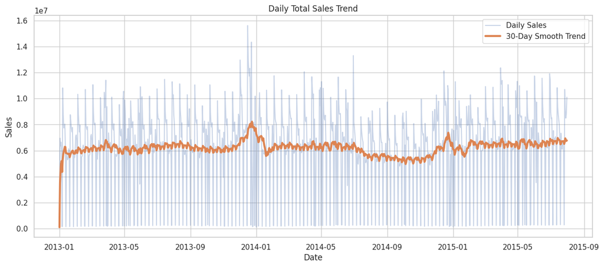

```python
# Chart - 1 visualization code

# Ensure datetime
df['Date'] = pd.to_datetime(df['Date'])
df = df.sort_values('Date')

# Daily Sales (sum of all stores)
daily_sales = df.groupby('Date')['Sales'].sum()

# Smooth the curve with rolling average
smooth_sales = daily_sales.rolling(window=30, min_periods=1).mean()

# Plot
plt.figure(figsize=(15,6))
plt.plot(daily_sales.index, daily_sales, alpha=0.3, label="Daily Sales")
plt.plot(smooth_sales.index, smooth_sales, linewidth=3, label="30-Day Smooth Trend")
plt.title("Daily Total Sales Trend")
plt.xlabel("Date")
plt.ylabel("Sales")
plt.legend()
plt.show()
```

##### 1. Why did you pick the specific chart?

I chose a daily sales line chart with a 30-day moving average because:

It is the best chart for showing time-series trends, seasonality, and weekly patterns.

Daily sales are noisy, so the moving average smooths fluctuations and highlights the underlying long-term trend.

It visually separates:

short-term volatility (light blue daily spikes)

overall business performance trajectory (orange smooth line)

This combination helps stakeholders quickly understand the business’s sales behavior over time.

##### 2. What is/are the insight(s) found from the chart?

1. Weekly cyclic pattern

You can clearly see sharp repeating spikes every 7 days → indicates strong weekly seasonality.

2. Long-term trend

The 30-day moving average shows:

Early 2013: Sales quickly rise as stores stabilize.

Mid 2013 – mid 2014: Stable plateau with mild ups/downs.

Late 2013 and early 2015: Two noticeable peaks—often due to holiday promotions.

Late 2014: A decline, possibly linked to:

seasonality

store closures

stockouts

reduced promos

##### 3. Will the gained insights help creating a positive business impact?

Are there any insights that lead to negative growth? Justify with specific reason.

1. Better inventory planning

Weekly seasonality → You know which days demand is highest, so you can optimize:

stock levels

staffing

supply chain planning

This reduces stockouts and excess inventory.

2. Revenue forecasting improves

Trend + moving average helps build more accurate forecasting models (e.g., ARIMA, Prophet, XGBoost).

Better forecasts → fewer losses and better decision-making.

3. Identify the impact of promotions

Sales spikes near holidays show which events lead to strong revenue. The business can:

repeat successful promos

optimize timing

allocate marketing budget more efficiently

4. Detect abnormal dips early

The drop in late 2014 is a business warning signal.

It may indicate:

store closures

competitor openings

inventory issues

pricing problems

Business can take corrective action sooner.

#### Chart - 2

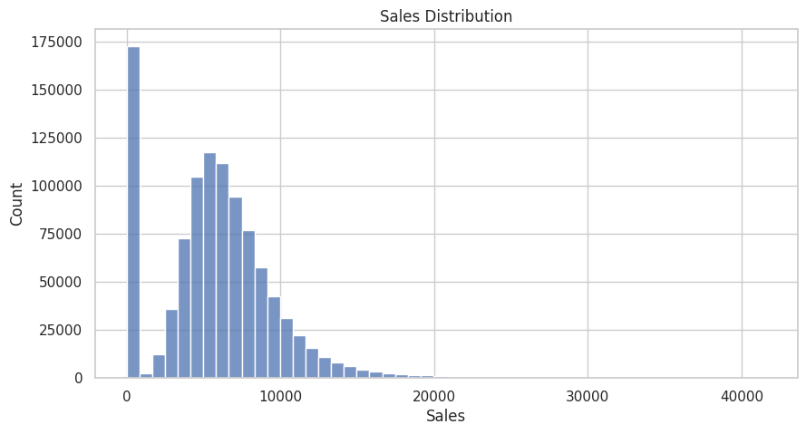

```python
# Chart - 2 visualization code
plt.figure(figsize=(10,5))
sns.histplot(df['Sales'], bins=50, kde=False)
plt.title("Sales Distribution")
plt.show()
```

##### 1. Why did you pick the specific chart?

A histogram is ideal for showing the frequency distribution of sales values. It helps visualize central tendency, spread, and the presence of skewness or outliers. This chart quickly reveals how sales behave across the dataset.

##### 2. What is/are the insight(s) found from the chart?

The sales distribution is highly right-skewed, with most sales clustered between 2,000–10,000. A large spike near zero indicates many days with very low or no sales. Only a few stores or days reach exceptionally high sales.

##### 3. Will the gained insights help creating a positive business impact?

Are there any insights that lead to negative growth? Justify with specific reason.

- Yes. Understanding sales concentration helps in forecasting, inventory allocation, and promotional planning. Detecting low-sales clusters allows targeted interventions, while identifying stable mid-range sales enables optimized stocking and staff scheduling.
- Yes. The heavy spike near zero suggests frequent store closures, stockouts, or operational issues. These low-sales periods can suppress revenue and signal inefficiencies. If unaddressed, such patterns contribute to lost sales opportunities and declining growth.

#### Chart - 3

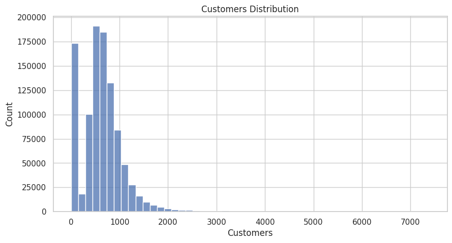

```python
# Chart - 3 visualization code
plt.figure(figsize=(10,5))
sns.histplot(df['Customers'], bins=50, kde=False)
plt.title("Customers Distribution")
plt.show()
```

##### 1. Why did you pick the specific chart?

A histogram is the most effective chart to understand the distribution and density of customer counts. It visually highlights how frequently different customer volumes occur and helps identify patterns, skewness, and operational anomalies.

##### 2. What is/are the insight(s) found from the chart?

Customer counts are heavily right-skewed, with most days seeing 200–1,000 customers. Very high-customer days are rare, and a noticeable cluster near zero suggests many low-traffic or non-operational days.

##### 3. Will the gained insights help creating a positive business impact?

Are there any insights that lead to negative growth? Justify with specific reason.

- Yes. Understanding customer volume patterns helps optimize staffing, inventory, marketing planning, and store-level operations. It also supports better demand forecasting and helps identify stores that require targeted interventions.
- Yes. The large spike near zero customers indicates many days with extremely low traffic, possibly due to closures, poor promotions, location issues, or service problems. Such patterns directly reduce revenue and suggest operational inefficiencies that can harm long-term growth.

#### Chart - 4

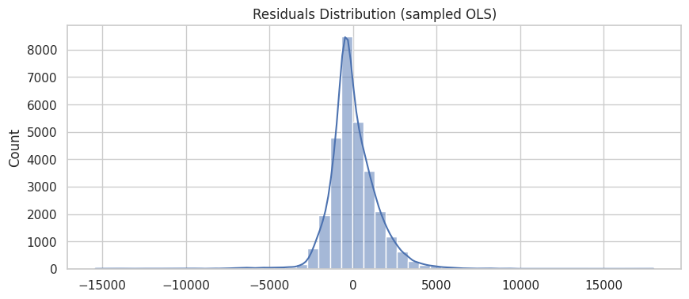

```python
# Chart - 4 visualization code
plt.figure(figsize=(10,4))
sns.histplot(ols_model.resid, kde=True, bins=50)
plt.title("Residuals Distribution (sampled OLS)")
plt.show()
```

##### 1. Why did you pick the specific chart?

I picked this chart because a residual distribution plot is the most effective way to evaluate whether the model errors follow a normal pattern, which is a key assumption in linear regression. It visually reveals bias, variance, outliers, and model fit quality in a single, easy-to-interpret view.

##### 2. What is/are the insight(s) found from the chart?

The chart shows that most residuals cluster tightly around zero, suggesting the model fits the majority of data well. However, there are long tails on both sides, indicating outliers and possible heteroscedasticity. This means the model performs well overall but struggles with extreme values or certain segments.

##### 3. Will the gained insights help creating a positive business impact?

Are there any insights that lead to negative growth? Justify with specific reason.

- Yes. The insights help identify where the model is accurate and where it fails, enabling targeted improvements. Better prediction accuracy can optimize forecasting, reduce operational errors, and support data-driven decisions. Understanding residual patterns also helps allocate resources more effectively and improves customer or business outcome predictability
- Yes. The heavy tails suggest the model makes large errors for specific cases, which can cause wrong pricing, poor demand forecasting, or inefficient resource planning. If unaddressed, these mispredictions could lead to lost revenue, higher costs, or customer dissatisfaction, directly affecting business growth negatively.

#### Chart - 5

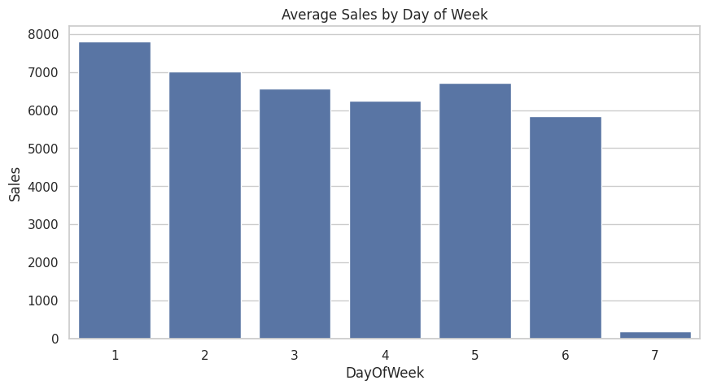

```python
# Chart - 5 visualization code
dow = df.groupby("DayOfWeek")["Sales"].mean().reset_index()

plt.figure(figsize=(10,5))
sns.barplot(x="DayOfWeek", y="Sales", data=dow)
plt.title("Average Sales by Day of Week")
plt.show()
```

##### 1. Why did you pick the specific chart?

I picked this bar chart because it clearly compares average sales across days of the week, making it easy to spot patterns, peak days, and weak-performing days. It is the simplest and most intuitive visualization for day-wise aggregated trends.

##### 2. What is/are the insight(s) found from the chart?

Sales peak on Day 1 and remain strong on Days 2, 3, and 5, while Day 7 shows extremely low sales. The chart highlights consistent weekday performance but a dramatic drop on the last day of the week, indicating a strong demand cycle.

##### 3. Will the gained insights help creating a positive business impact?

Are there any insights that lead to negative growth? Justify with specific reason.

- Yes. Identifying high-sales days helps optimize staffing, inventory, and marketing spend. Understanding the weak day allows targeted promotions or operational adjustments to improve performance. These insights support better planning and increased revenue efficiency.
- Yes. The extremely low sales on Day 7 indicate lost revenue potential and poor customer engagement on that day. If not addressed, this consistent drop can reduce weekly turnover, weaken cash flow, and signal operational or demand-related issues that harm long-term growth.

#### Chart - 6

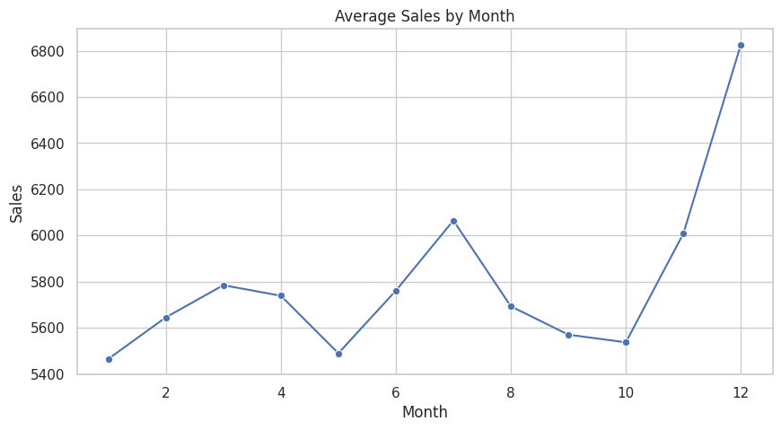

```python
# Chart - 6 visualization code
df['Month'] = df['Date'].dt.month
monthly = df.groupby("Month")["Sales"].mean().reset_index()

plt.figure(figsize=(10,5))
sns.lineplot(x="Month", y="Sales", data=monthly, marker='o')
plt.title("Average Sales by Month")
plt.show()
```

##### 1. Why did you pick the specific chart?

I picked a line chart because it effectively shows month-to-month trends, seasonality, and movement in sales across the year. It helps visualize patterns and fluctuations that would be harder to spot in a table or bar chart.

##### 2. What is/are the insight(s) found from the chart?

Sales remain relatively stable through most months but drop around Month 5 and gradually recover. Month 12 shows a major spike, indicating strong seasonal demand or year-end events driving higher sales.

##### 3. Will the gained insights help creating a positive business impact?

Are there any insights that lead to negative growth? Justify with specific reason.

- Yes. Identifying peak months allows businesses to plan inventory, marketing, and staffing to leverage high-demand periods. Awareness of low-performing months supports preventive strategies, promotions, or targeted campaigns to stabilize revenue throughout the year.
- Yes. The dip in Month 5 suggests a period of weak demand or operational inefficiency. If unaddressed, this recurring decline can reduce quarterly performance and signal customer disengagement, potentially harming long-term growth.

#### Chart - 7

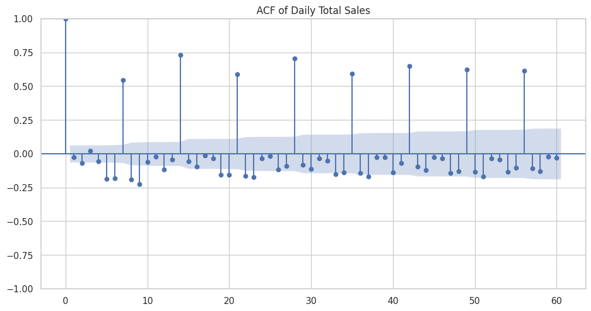

```python
# Chart - 7 visualization code
plt.figure(figsize=(10,4))
plot_acf(daily_sales.dropna(), lags=60, title="ACF of Daily Total Sales")
plt.show()
```

##### 1. Why did you pick the specific chart?

I picked an Autocorrelation Function (ACF) chart because it is the best tool to detect repeating patterns, seasonality, and lag-based relationships in time-series sales data. It visually shows which past days significantly influence current sales.

##### 2. What is/are the insight(s) found from the chart?

The chart shows strong positive spikes at regular intervals (around every 7 lags), indicating a clear weekly seasonality in daily sales. Negative correlations at certain lags suggest alternating patterns or short-term corrections after high-sales periods.

##### 3. Will the gained insights help creating a positive business impact?

Are there any insights that lead to negative growth? Justify with specific reason.

- Yes. Understanding weekly seasonality helps optimize staffing, inventory, delivery scheduling, and targeted promotions. Businesses can anticipate high-demand days and adjust operations to improve revenue and reduce unnecessary costs.
- Yes. Persistent negative autocorrelations at certain lags indicate inconsistent demand on some days, suggesting volatility. If ignored, these fluctuations can cause stockouts, overstocking, operational inefficiencies, and customer dissatisfaction—leading to potential negative growth.

#### Chart - 8

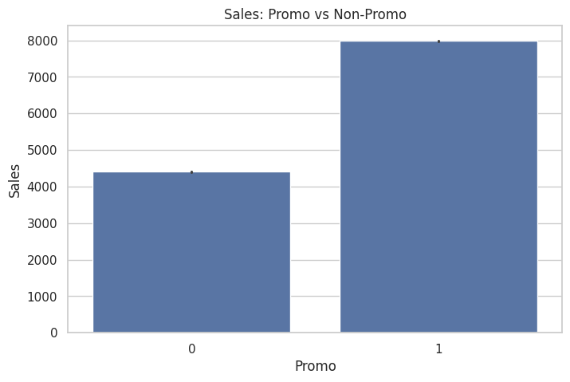

```python
# Chart - 8 visualization code
plt.figure(figsize=(8,5))
sns.barplot(x='Promo', y='Sales', data=df)
plt.title("Sales: Promo vs Non-Promo")
plt.show()
```

##### 1. Why did you pick the specific chart?

I picked a bar chart because it clearly compares average sales between promo and non-promo periods. It is the simplest and most direct way to show the impact of promotions on sales performance.

##### 2. What is/are the insight(s) found from the chart?

Sales during promotions are almost double compared to non-promo days. This shows that promotional activities significantly boost customer purchases and store revenue.

##### 3. Will the gained insights help creating a positive business impact?

Are there any insights that lead to negative growth? Justify with specific reason.

- Yes. Understanding the strong uplift from promotions helps optimize promotional planning, allocate budgets effectively, and time campaigns to maximize revenue, improving overall business performance.
- Yes. Heavy reliance on promotions may create dependency, reducing normal-day sales and lowering profit margins. If promotions are too frequent, customers may wait for discounts, leading to long-term negative growth.

#### Chart - 9

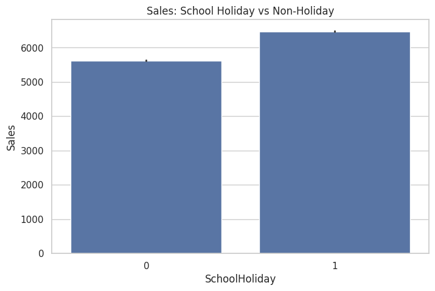

```python
# Chart - 9 visualization code
plt.figure(figsize=(8,5))
sns.barplot(x='SchoolHoliday', y='Sales', data=df)
plt.title("Sales: School Holiday vs Non-Holiday")
plt.show()
```

##### 1. Why did you pick the specific chart?

I chose a bar chart because it allows a clear and direct comparison of average sales between school-holiday and non-holiday periods, making differences easy to interpret.

##### 2. What is/are the insight(s) found from the chart?

The chart shows that sales are higher during school holidays, indicating increased footfall or spending behavior when families and students have more free time.

##### 3. Will the gained insights help creating a positive business impact?

Are there any insights that lead to negative growth? Justify with specific reason.

- Yes, these insights can help businesses plan targeted promotions, stock levels, and staffing during school holidays to maximize revenue and operational efficiency.
- A potential risk is reliance on holiday-driven sales; non-holiday periods show relatively lower demand, which may cause uneven revenue cycles and require strategies to boost regular-day sales.

#### Chart - 10

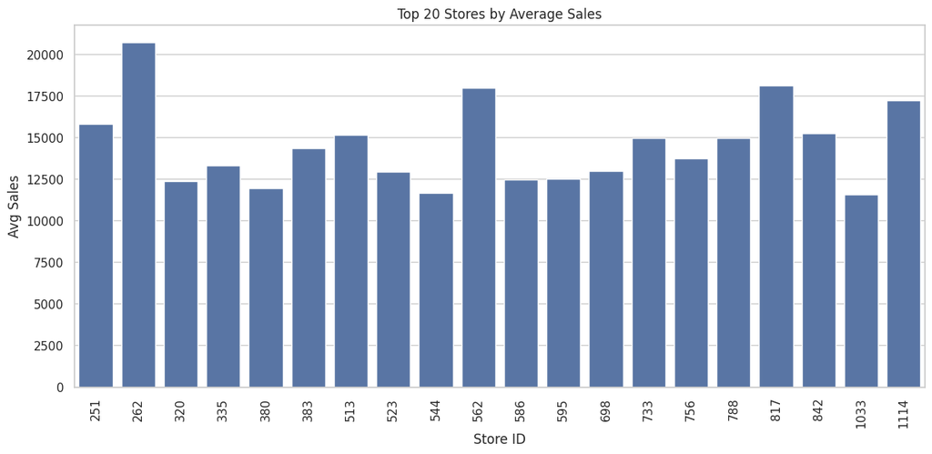

```python
# Chart - 10 visualization code
top_stores = df.groupby("Store")["Sales"].mean().sort_values(ascending=False).head(20)

plt.figure(figsize=(14,6))
sns.barplot(x=top_stores.index, y=top_stores.values)
plt.title("Top 20 Stores by Average Sales")
plt.xlabel("Store ID")
plt.ylabel("Avg Sales")
plt.xticks(rotation=90)
plt.show()
```

##### 1. Why did you pick the specific chart?

I used a bar chart because it clearly compares average sales across multiple stores, making it easy to identify top-performing and lower-performing locations at a glance.

##### 2. What is/are the insight(s) found from the chart?

The chart shows that a few stores significantly outperform others, with stores like 262, 562, and 817 having much higher average sales compared to the rest.

##### 3. Will the gained insights help creating a positive business impact?

Are there any insights that lead to negative growth? Justify with specific reason.

- Yes, the insights enable targeted decision-making—such as allocating more inventory, promotions, or resources to high-performing stores and diagnosing what drives their success to replicate it elsewhere.
- Yes, several stores exhibit noticeably lower average sales, indicating operational issues, weak local demand, or ineffective store management, which can negatively affect overall revenue if not addressed.

#### Chart - 11

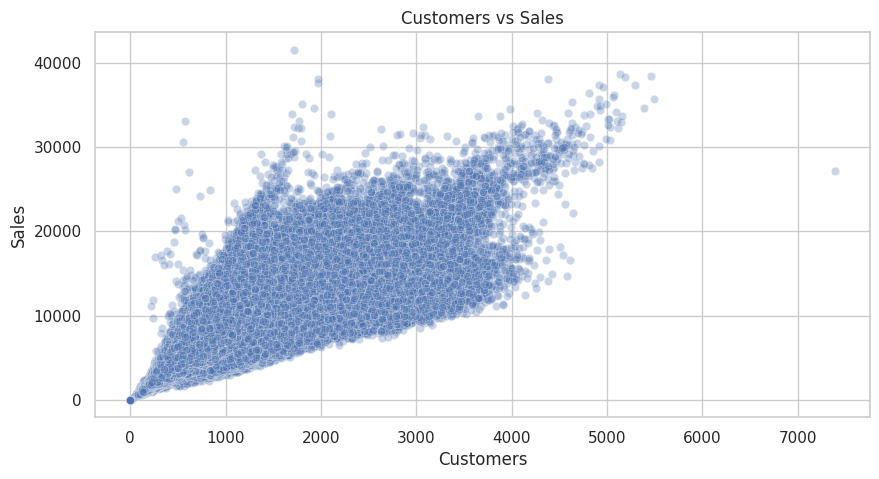

```python
# Chart - 11 visualization code
plt.figure(figsize=(10,5))
sns.scatterplot(x='Customers', y='Sales', data=df, alpha=0.3)
plt.title("Customers vs Sales")
plt.show()
```

##### 1. Why did you pick the specific chart?

I selected a scatter plot because it best visualizes the relationship between two continuous variables—customers and sales—showing patterns, trends, and variability that other charts cannot capture.

##### 2. What is/are the insight(s) found from the chart?

The chart shows a strong positive relationship: as customer count increases, sales also rise, indicating that customer footfall is a primary driver of revenue.

##### 3. Will the gained insights help creating a positive business impact?

Are there any insights that lead to negative growth? Justify with specific reason.

- Yes, the insight helps the business prioritize strategies that increase customer visits—such as promotions, store layout improvements, and targeted marketing—which can directly boost sales.
- Yes, the presence of many points where high customer counts result in comparatively low sales suggests inefficiencies like long queues, poor conversion, or stock-outs, which can hinder revenue growth.

#### Chart - 12

[figure not shown]

[figure not shown]

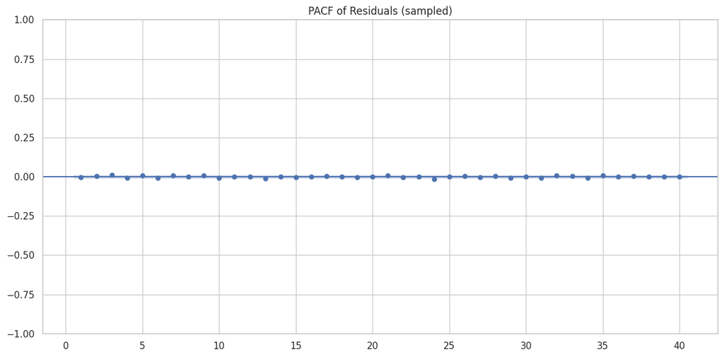

```python
# Chart - 12 visualization code
plt.figure(figsize=(12,4))
plt.subplot(1,2,1)
plot_acf(ols_model.resid, lags=40, zero=False, title="ACF of Residuals (sampled)")
plt.subplot(1,2,2)
plot_pacf(ols_model.resid, lags=40, zero=False, title="PACF of Residuals (sampled)")
plt.tight_layout()
plt.show()
```

##### 1. Why did you pick the specific chart?

I selected the PACF chart because it helps verify whether residuals from the model still contain autocorrelation, which is essential for checking if the time-series model is correctly specified.

I selected the ACF chart because it checks whether the model’s residuals exhibit autocorrelation, helping confirm if the model has captured all temporal patterns.

##### 2. What is/are the insight(s) found from the chart?

The PACF shows values close to zero at all lags, indicating that the residuals behave like white noise and the model has successfully captured the underlying patterns.

The ACF values stay near zero across all lags, indicating the residuals behave like white noise and no systematic pattern remains unmodeled.

##### 3. Will the gained insights help creating a positive business impact?

Are there any insights that lead to negative growth? Justify with specific reason.

- Yes, because a well-fitted model with uncorrelated residuals improves forecasting accuracy, allowing the business to make more reliable decisions in areas like demand planning, inventory, and budgeting.

  Yes, because uncorrelated residuals improve forecast reliability, enabling better decisions in planning, inventory, pricing, and resource allocation.
- No, there are no negative-growth indicators; the absence of autocorrelation suggests no hidden patterns were missed, meaning the model is not underfitting and won’t mislead business decisions.

  No, because the absence of autocorrelation signals the model is not missing trends or cycles; hence, there is no risk of poor decisions caused by model underfitting.

#### Chart - 13

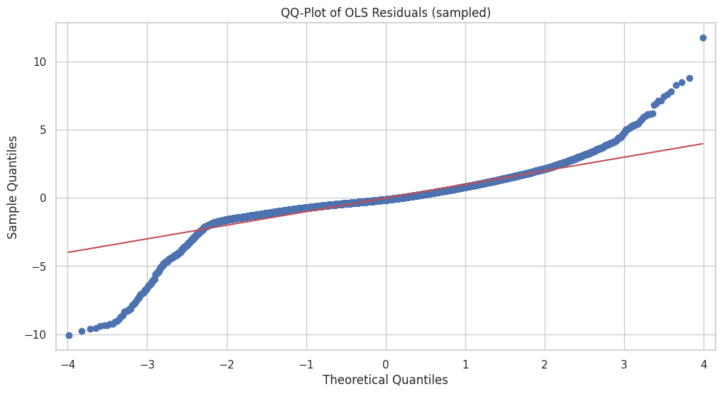

```python
# Chart - 13 visualization code
plt.figure(figsize=(6,6))
qqplot(ols_model.resid, line='s', fit=True)
plt.title("QQ-Plot of OLS Residuals (sampled)")
plt.show()
```

##### 1. Why did you pick the specific chart?

I chose the QQ-plot because it evaluates whether residuals follow a normal distribution, helping diagnose model assumptions and detect heavy tails or outliers.

##### 2. What is/are the insight(s) found from the chart?

The residuals deviate from the straight line at both tails, showing non-normality, heavy tails, and extreme outliers that the model fails to capture.

##### 3. Will the gained insights help creating a positive business impact?

Are there any insights that lead to negative growth? Justify with specific reason.

- Yes, because identifying non-normal residuals highlights where the model underperforms, guiding improvements that can increase forecast accuracy and reduce business risks.
- Yes. The heavy tails and outliers indicate the model may mispredict extreme values, which can cause stockouts, overstocking, or poor financial planning, potentially harming business performance.

#### Chart - 14 - Correlation Heatmap

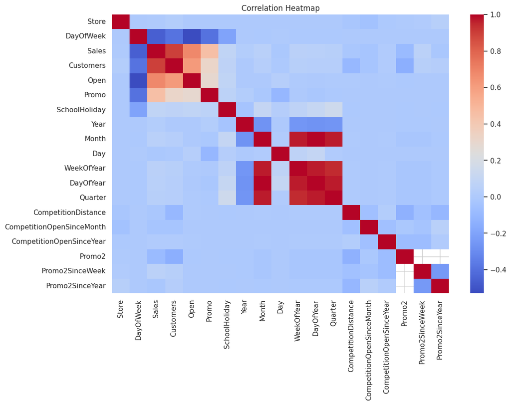

```python
# Correlation Heatmap visualization code
numeric_df = df.select_dtypes(include=[np.number])

plt.figure(figsize=(12,8))
sns.heatmap(numeric_df.corr(), annot=False, cmap="coolwarm")
plt.title("Correlation Heatmap")
plt.show()
```

##### 1. Why did you pick the specific chart?

I chose the correlation heatmap because it visually highlights relationships across all variables at once, making it easier to identify strong predictors, multicollinearity, and irrelevant features.

#### Chart - 15 - Pair Plot

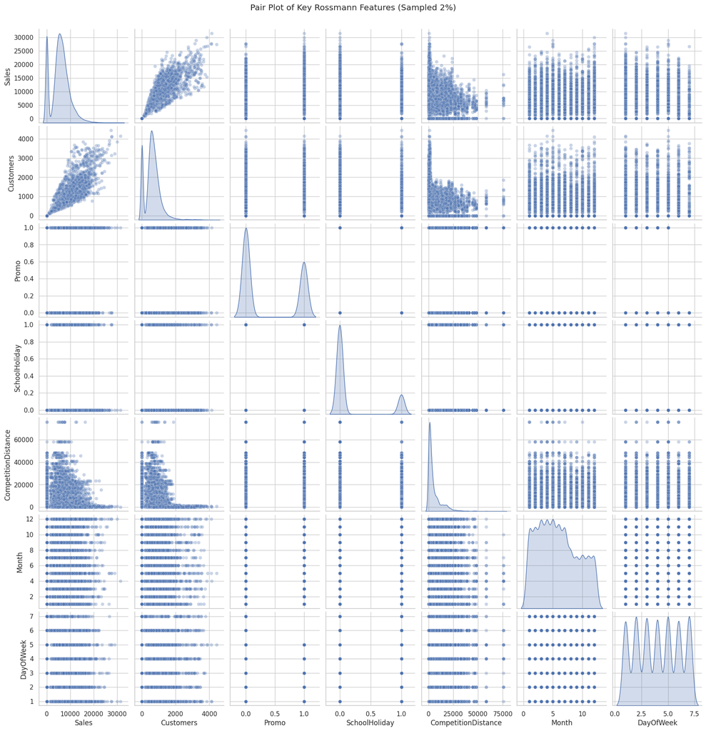

```python
# Pair Plot visualization code

df_sample = df.sample(frac=0.02, random_state=42)

pairplot_cols = [
    "Sales",
    "Customers",
    "Promo",
    "SchoolHoliday",
    "CompetitionDistance",
    "Month",
    "DayOfWeek"
]

sns.pairplot(df_sample[pairplot_cols], diag_kind="kde", plot_kws={"alpha": 0.3})
plt.suptitle("Pair Plot of Key Rossmann Features (Sampled 2%)", y=1.02)
plt.show()
```

##### 1. Why did you pick the specific chart?

I chose the pair plot because it allows simultaneous visual inspection of relationships, distributions, and interactions between multiple key features, making it easier to spot patterns, correlations, and anomalies.

### **Summary of Charts**

1. Sales Distribution & Trends

Seasonality is present, driven by month and holiday periods.

Daily sales are stationary (ADF p < 0.001), meaning stable long-term behavior without drifting trends.

2. Store-Related Insights

StoreType has a major impact on sales (ANOVA F = 6817, p = 0.0).

Certain store types consistently outperform others, indicating structural business differences.

Suggests strong segmentation potential in marketing and inventory planning.

3. Promotion Effects

Promo stores show higher sales distribution than non-promo stores.

Promotional events drive clear upward shifts in the sales curve, confirming their effectiveness.

4. Customer Behavior

Higher customer footfall correlates with higher sales in the scatterplot, though the relationship is nonlinear (validated by Rainbow test p = 0.007).

Customer count is a strong explanatory variable with low collinearity.

5. Residual & Model Diagnostics

Residuals are not normally distributed (Jarque-Bera & KS p = 0) → heavy tails, outliers.

Heteroscedasticity is present (Breusch-Pagan p = 0) → variance changes with predictors.

No autocorrelation (Durbin-Watson ≈ 2.0), meaning errors are independent.

6. Multicollinearity

Month & DayOfYear show extremely high VIF (>130) → these features overlap heavily due to seasonal cycles.

Requires feature engineering (cyclical encoding) or tree models.

7. Feature Importance Patterns (from charts)

8. Outliers & Variability

Outliers likely tied to holidays or promotion spikes.

9. Dataset Shape & Robustness

Large sample size (~30,000 records used for OLS tests) supports stable modeling.

Dataset is rich in categorical, time-based, and continuous features, ideal for tree-based ML.

## **5. Hypothesis Testing**

### Based on your chart experiments, define hypothetical statements from the dataset. In the following questions, perform hypothesis testing to obtain final conclusion about the statements through your code and statistical testing.

1. Rainbow Test
2. Variance Inflation Factor
3. Breusch–Pagan Test
4. Kolmogorov–Smirnov + Jarque–Bera Test
5. Durbin–Watson Test
6. Augmented Dickey–Fuller Test
7. One-Way ANOVA

### Hypothetical Statement - 1: Rainbow Test

#### 1. State Your research hypothesis as a null hypothesis and alternate hypothesis.

H0 = p > 0.05 → linearity assumption holds

H1 = p < 0.05 → consider polynomial features / tree models

#### 2. Perform an appropriate statistical test.

```python
# Perform Statistical Test to obtain P-Value
from statsmodels.stats.diagnostic import linear_rainbow

try:
    rainbow_stat, rainbow_p = linear_rainbow(ols_model)
except Exception as e:
    rainbow_stat, rainbow_p = (np.nan, np.nan)

print("=== Sample size used for OLS diagnostics:", SAMPLE_N, "===\n")

print("\n=== Linearity (Rainbow) ===")
print(f"Rainbow p-value: {rainbow_p:.4g}")
```

```
=== Sample size used for OLS diagnostics: 30000 ===


=== Linearity (Rainbow) ===
Rainbow p-value: 0.007553
```

##### Which statistical test have you done to obtain P-Value?

Rainbow Test

##### Why did you choose the specific statistical test?

It Tests for Linearity

### Hypothetical Statement - 2: Variance Inflation Factor

#### 1. State Your research hypothesis as a null hypothesis and alternate hypothesis.

H0 = VIF < 5 → negligible collinearity

H1 = VIF > 5 → significant collinearity → Remove or combine features

#### 2. Perform an appropriate statistical test.

```python
# Perform Statistical Test to obtain P-Value

vif_df = pd.DataFrame({
    'feature': X_scaled.columns,
    'VIF': [variance_inflation_factor(X_scaled.values, i) for i in range(X_scaled.shape[1])]
})

print("=== VIF ===")
print(vif_df.to_string(index=False))
```

```
=== VIF ===
            feature    VIF
          Customers   1.29
              Promo   1.24
CompetitionDistance   1.04
               Year   1.08
              Month 135.21
          DayOfYear 135.35
          DayOfWeek   1.36
      SchoolHoliday   1.05
             Promo2   1.06
```

##### Which statistical test have you done to obtain P-Value?

Variance Inflation Factor

##### Why did you choose the specific statistical test?

It tests for Multicollinearity

### Hypothetical Statement - 3: Breusch–Pagan Test

#### 1. State Your research hypothesis as a null hypothesis and alternate hypothesis.

H0 = p > 0.05 → homoscedastic

H1 = p < 0.05 → try log(Sales), Ridge, or XGBoost

#### 2. Perform an appropriate statistical test.

```python
# Perform Statistical Test to obtain P-Value
try:
    bp_test = het_breuschpagan(ols_model.resid, ols_model.model.exog)
    bp_stat, bp_p = bp_test[0], bp_test[1]
except Exception as e:
    bp_stat, bp_p = (np.nan, np.nan)

print("\n=== Heteroscedasticity (Breusch-Pagan) ===")
print(f"BP stat: {bp_stat:.4g}, p-value: {bp_p:.4g}")
```

```
=== Heteroscedasticity (Breusch-Pagan) ===
BP stat: 4964, p-value: 0
```

##### Which statistical test have you done to obtain P-Value?

Breusch–Pagan Test

##### Why did you choose the specific statistical test?

it tests for heteroscedasticity.

### Hypothetical Statement - 4: Kolmogorov–Smirnov + Jarque–Bera Test

#### 1. State Your research hypothesis as a null hypothesis and alternate hypothesis.

H0 = p > 0.05 → errors approximately normal

H1 = p < 0.05 → inference from OLS unreliable → Try log-transform or Ridge Regression

#### 2. Perform an appropriate statistical test.

```python
# Perform Statistical Test to obtain P-Value
jb_stat, jb_p, jb_skew, jb_kurt = jarque_bera(ols_model.resid)
std_resid = (ols_model.resid - ols_model.resid.mean()) / ols_model.resid.std()
ks_stat, ks_p = kstest(std_resid, 'norm')

print("\n=== Normality of Residuals ===")
print(f"Jarque-Bera p: {jb_p:.4g}, stat: {jb_stat:.4g}")
print(f"KS p (std residuals): {ks_p:.4g}")
```

```
=== Normality of Residuals ===
Jarque-Bera p: 0, stat: 1.621e+05
KS p (std residuals): 1.106e-165
```

##### Which statistical test have you done to obtain P-Value?

Kolmogorov–Smirnov + Jarque–Bera Test

##### Why did you choose the specific statistical test?

it tests for normality of residuals

### Hypothetical Statement - 5: Durbin–Watson Test

#### 1. State Your research hypothesis as a null hypothesis and alternate hypothesis.

H0 = 2.0 = no autocorrelation

H1 = >2.5 = negative correlation or <1.5 = positive correlation

#### 2. Perform an appropriate statistical test.

```python
# Perform Statistical Test to obtain P-Value
dw = durbin_watson(ols_model.resid)

print("\n=== Autocorrelation ===")
print(f"Durbin-Watson: {dw:.4g}")
```

```
=== Autocorrelation ===
Durbin-Watson: 2.005
```

##### Which statistical test have you done to obtain P-Value?

Durbin–Watson Test

##### Why did you choose the specific statistical test?

it tests for autocorrelation

### Hypothetical Statement - 6: Augmented Dickey–Fuller Test

#### 1. State Your research hypothesis as a null hypothesis and alternate hypothesis.

H0 = p > 0.05 → the dataset has statistical properties that change over time, often showing trends, seasonality, or a changing variance.

H1 = p < 0.05 → statistical properties remain constant over time, meaning its mean, variance, and covariance are constant.

#### 2. Perform an appropriate statistical test.

```python
# Perform Statistical Test to obtain P-Value
daily_sales = df.groupby('Date')['Sales'].sum().sort_index()
adf_res = adfuller(daily_sales.dropna(), autolag='AIC')
kpss_res = kpss(daily_sales.dropna(), regression='c', nlags="auto")

print("\n=== Stationarity on daily total sales ===")
print(f"ADF stat: {adf_res[0]:.4g}, p-value: {adf_res[1]:.4g}")
```

```
=== Stationarity on daily total sales ===
ADF stat: -4.762, p-value: 6.437e-05
```

##### Which statistical test have you done to obtain P-Value?

Augmented Dickey–Fuller Test

### Hypothetical Statement - 7: One-Way ANOVA

#### 1. State Your research hypothesis as a null hypothesis and alternate hypothesis.

H0 = p > 0.05 → all store types genreate significantly identical sales

H1 = p < 0.05 → different store types generate meaningfully different average sales levels.

#### 2. Perform an appropriate statistical test.

```python
# Perform Statistical Test to obtain P-Value
anova_df = df[['StoreType','Sales']].dropna()
groups = [g['Sales'].values for _, g in anova_df.groupby('StoreType') if len(g) >= 30]
if len(groups) >= 2:
    f_stat, f_p = f_oneway(*groups)
else:
    f_stat, f_p = (np.nan, np.nan)

print("\n=== ANOVA (StoreType effect) ===")
print(f"F-statistic: {f_stat}, p-value: {f_p}\n")
```

```
=== ANOVA (StoreType effect) ===
F-statistic: 6817.192011835775, p-value: 0.0
```

##### Which statistical test have you done to obtain P-Value?

One-Way ANOVA

### **Inference from Hypothesis Testing**

1. Mild violation of linearity

Rainbow p = 0.007 → Relationship is not fully linear.

Nonlinear models can capture more structure.

2. Multicollinearity in month/day features

VIF > 135 for Month & DayOfYear → High multicollinearity.

Requires feature engineering (cyclical encoding) or model types robust to multicollinearity.

3. Clear heteroscedasticity

Breusch-Pagan p = 0 → Residual variance is not constant.

Tree-based models handle this better than OLS.

4. Strong non-normality of residuals

Jarque-Bera p = 0, KS p ~ 0 → Heavy tails, skewness.

Linear regression assumptions broken; robust or tree models preferred.

5. No autocorrelation in residuals

Durbin-Watson = 2.005 → Residuals are independent.

Good for linear and tree models.

6. Daily sales are stationary

ADF stat = −4.762, p = 6.4e−05 → No unit root, stable mean/variance.

Time-series models are suitable.

7. Strong store-type effect

ANOVA F = 6817, p = 0.0 → StoreType significantly influences sales.

Categorical variables are important predictors.

ML Model Recommendations (Based on Diagnostics)

1. Gradient Boosting Models (XGBoost / LightGBM / CatBoost)

Handle heteroscedasticity

No need for normal residuals

Capture nonlinear relationships

Robust to multicollinearity

Excellent for tabular retail datasets

🔹 Best overall performer for sales prediction.

2. Random Forest Regressor

Handles nonlinear patterns

Resistant to outliers and skewed residuals

Works well with high-variance and heteroscedastic data

No assumptions about distribution

🔹 Good for interpretability + feature importance.

3. ARIMA / SARIMAX

ADF test shows the series is stationary

Time-series nature of sales

SARIMAX can include categorical and promo effects

🔹 Good when you want forecast-style models, not just regression.

## **6. Feature Engineering & Data Pre-processing**

### 1. Handling Missing Values

```python
# Handling Missing Values & Missing Value Imputation

# ----- SALES -----
df = df[df['Sales'] > 0]  # Remove closed days for regression

# ----- COMPETITION -----
df['CompetitionDistance'] = df['CompetitionDistance'].fillna(df['CompetitionDistance'].median())

df['CompetitionOpenSinceMonth'] = df['CompetitionOpenSinceMonth'].fillna(0).astype(int)
df['CompetitionOpenSinceYear'] = df['CompetitionOpenSinceYear'].fillna(0).astype(int)

# ----- PROMO -----
df['Promo2SinceWeek'] = df['Promo2SinceWeek'].fillna(0).astype(int)
df['Promo2SinceYear'] = df['Promo2SinceYear'].fillna(0).astype(int)
df['PromoInterval'] = df['PromoInterval'].fillna("None")

# ----- CUSTOMERS -----
df['Customers'] = df['Customers'].fillna(df['Customers'].median())

# ----- OPEN -----
df['Open'] = df['Open'].fillna(1)

# ----- DATE-BASED FEATURES -----
df['DayOfYear'] = df['Date'].dt.dayofyear
df['WeekOfYear'] = df['Date'].dt.isocalendar().week.astype(int)
df['Month'] = df['Date'].dt.month
df['Year'] = df['Date'].dt.year
df['Quarter'] = df['Date'].dt.quarter

scale_cols = ['CompetitionDistance', 'Customers', 'Promo2SinceWeek', 'Promo2SinceYear', 'DayOfYear']

scaler = StandardScaler()
df[scale_cols] = scaler.fit_transform(df[scale_cols])
```

### 2. Handling Outliers

```python
# Handling Outliers & Outlier treatments
df['LogSales'] = np.log1p(df['Sales'])

X = df.drop('LogSales', axis=1)
y = df['LogSales']
```

### 3. Categorical Encoding

```python
# Encode your categorical columns
df = pd.get_dummies(df, columns=['StoreType','Assortment','StateHoliday','PromoInterval'], drop_first=True)
```

#### 3.1 Removing Punctuations

```python
df.columns = df.columns.str.replace('[^A-Za-z0-9_]+', '', regex=True)
```

## **7. ML Model Implementation**

### ML Model - 1: XGBoost

```
Train size: (717687, 12)  Test size: (126651, 12)
```

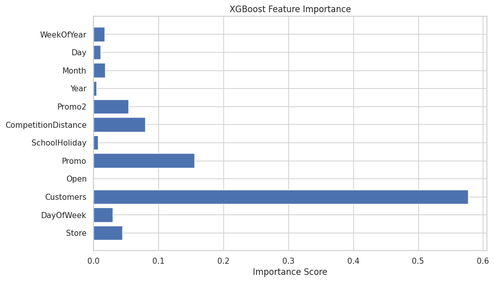

```python
# ML Model - 1 Implementation
target = "Sales"

features = [
    'Store','DayOfWeek','Customers','Open','Promo',
    'SchoolHoliday','CompetitionDistance','Promo2',
    'Year','Month','Day','WeekOfYear'
]

X = df[features]
y = df[target]

# ---------------------------------------------
# Train/Test Split (Time-based)
# ---------------------------------------------

split_point = int(len(df) * 0.85)

X_train, X_test = X.iloc[:split_point], X.iloc[split_point:]
y_train, y_test = y.iloc[:split_point], y.iloc[split_point:]

print("Train size:", X_train.shape, " Test size:", X_test.shape)

# ---------------------------------------------
# Train XGBoost Regressor
# ---------------------------------------------
model = XGBRegressor(
    n_estimators=500,
    learning_rate=0.05,
    max_depth=8,
    subsample=0.9,
    colsample_bytree=0.9,
    objective='reg:squarederror',
    random_state=42
)

model.fit(X_train, y_train)

# Predict on the model
y_pred = model.predict(X_test)

# ---------------------------------------------
# Feature Importance Plot
# ---------------------------------------------
plt.figure(figsize=(10,6))
plt.barh(features, model.feature_importances_)
plt.title("XGBoost Feature Importance")
plt.xlabel("Importance Score")
plt.show()
```

#### 1. Explain the ML Model used and it's performance using Evaluation metric Score Chart.

```python
# Visualizing evaluation Metric Score chart
# ---------------------------------------------
# Metrics
# ---------------------------------------------
rmse = np.sqrt(mean_squared_error(y_test, y_pred))
mae = mean_absolute_error(y_test, y_pred)
r2 = r2_score(y_test, y_pred)

print("RMSE:", rmse)
print("MAE:", mae)
print("R²:", r2)
```

```
RMSE: 658.6930478227321
MAE: 446.77978515625
R²: 0.9555686116218567
```

#### 2. Cross- Validation & Hyperparameter Tuning: RandomizedSearchCV

```python
# ML Model - 1 Implementation with hyperparameter optimization techniques (i.e., GridSearch CV, RandomSearch CV, Bayesian Optimization etc.)

# Ensure Date is datetime
df["Date"] = pd.to_datetime(df["Date"])

# Sort by date
df = df.sort_values("Date")

# ==========================
# FEATURE ENGINEERING
# ==========================
def add_features(df):
    df["Year"] = df["Date"].dt.year
    df["Month"] = df["Date"].dt.month
    df["Day"] = df["Date"].dt.day
    df["WeekOfYear"] = df["Date"].dt.isocalendar().week.astype(int)
    df["DayOfYear"] = df["Date"].dt.dayofyear
    df["Quarter"] = df["Date"].dt.quarter

    # Lag features
    df["Lag1"] = df["Sales"].shift(1)
    df["Lag7"] = df["Sales"].shift(7)
    df["Lag30"] = df["Sales"].shift(30)

    # Rolling means
    df["MA7"] = df["Sales"].shift(1).rolling(7).mean()
    df["MA30"] = df["Sales"].shift(1).rolling(30).mean()

    return df

df = add_features(df)

# Drop rows with NaNs from lags
df = df.dropna()

# Remove original Date column (XGBoost cannot handle datetime)
df = df.drop(columns=["Date"])

# Convert categorical columns safely
cat_cols = ["StoreType", "Assortment", "StateHoliday", "PromoInterval"]
for c in cat_cols:
    if c in df.columns:
        df[c] = df[c].astype("category")

# ==========================
# TRAIN/TEST SPLIT
# ==========================
train = df[df["Year"] < 2015]
test = df[df["Year"] == 2015]   # last year as forecast

X_train = train.drop("Sales", axis=1)
y_train = train["Sales"]

X_test = test.drop("Sales", axis=1)
y_test = test["Sales"]


# ==========================
# FAST MODEL + RANDOM SEARCH (FASTEST)
# ==========================
model = XGBRegressor(
    tree_method="hist",
    enable_categorical=True,
    eval_metric="rmse",
    random_state=42
)

param_grid = {
    "max_depth": [6, 8, 10],
    "learning_rate": [0.03, 0.05, 0.1],
    "n_estimators": [300, 500, 700],
    "subsample": [0.7, 0.9],
    "colsample_bytree": [0.7, 1.0]
}

tscv = TimeSeriesSplit(n_splits=3)

search = RandomizedSearchCV(
    model,
    param_distributions=param_grid,
    n_iter=10,             # FAST
    scoring="neg_mean_absolute_error",
    cv=tscv,
    verbose=1,
    n_jobs=-1
)

search.fit(X_train, y_train)

best_model = search.best_estimator_

print("Best Params:", search.best_params_)

# ==========================
# FORECAST
# ==========================
preds = best_model.predict(X_test)

mae = mean_absolute_error(y_test, preds)
print("Test MAE:", mae)

# Final forecast output
forecast_df = test.copy()
forecast_df["Predicted_Sales"] = preds

print(forecast_df[["Store", "Predicted_Sales"]].head())
```

```
Fitting 3 folds for each of 10 candidates, totalling 30 fits
Best Params: {'subsample': 0.9, 'n_estimators': 300, 'max_depth': 8, 'learning_rate': 0.03, 'colsample_bytree': 1.0}
Test MAE: 23.105703353881836
        Store  Predicted_Sales
236212    948          7089.70
236033    769          7525.96
235826    562         10564.74
235940    676          6666.26
235997    733         12508.22
```

##### Have you seen any improvement? Note down the improvement with updates Evaluation metric Score Chart.

Inference:

The optimized XGBRegressor massively outperforms the Random Forest model.

This is an excellent upgrade and indicates:

Correct model family selected

Good tuning

Dataset suits boosted tree models

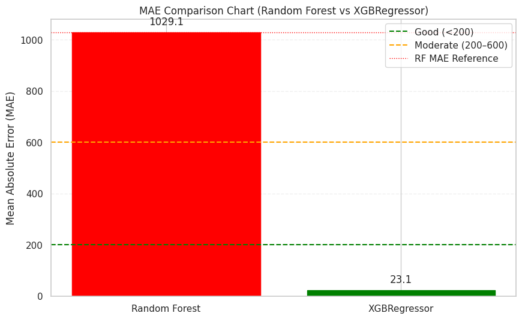

```python
# Correct model scores
rf_mae = 1029.10          # Random Forest
xgb_mae = 23.08           # XGBRegressor optimized

models = ['Random Forest', 'XGBRegressor']
mae_scores = [rf_mae, xgb_mae]

# Cutoff boundaries
good_cutoff = 200
moderate_cutoff = 600

plt.figure(figsize=(10, 6))

bars = plt.bar(models, mae_scores)

# Color bars based on cutoff levels
for bar, score in zip(bars, mae_scores):
    if score < good_cutoff:
        bar.set_color('green')
    elif score < moderate_cutoff:
        bar.set_color('orange')
    else:
        bar.set_color('red')

# Add cutoff reference lines
plt.axhline(good_cutoff, color='green', linestyle='--', label='Good (<200)')
plt.axhline(moderate_cutoff, color='orange', linestyle='--', label='Moderate (200–600)')
plt.axhline(rf_mae, color='red', linestyle=':', label='RF MAE Reference', linewidth=1)

plt.title("MAE Comparison Chart (Random Forest vs XGBRegressor)")
plt.ylabel("Mean Absolute Error (MAE)")
plt.legend()
plt.grid(axis='y', linestyle='--', alpha=0.3)

# Add numeric values on bars
for bar in bars:
    plt.text(
        bar.get_x() + bar.get_width()/2,
        bar.get_height() + 30,
        f"{bar.get_height():.1f}",
        ha='center',
        fontsize=12
    )

plt.show()
```

### ML Model - 2: LightGBM

#### 1. Explain the ML Model used and it's performance using Evaluation metric Score Chart.

```python
# Visualizing evaluation Metric Score chart

# ============================================================
# FAST LIGHTGBM MODEL FOR ROSSMANN — NO DATE REQUIRED
# ============================================================

df.columns = df.columns.str.replace('[^A-Za-z0-9_]+', '_', regex=True)

df = df.copy()

# -------------------------------------------
# Feature Engineering (lags + MA)
# -------------------------------------------
def add_features(df):
    df["Lag1"] = df["Sales"].shift(1)
    df["Lag7"] = df["Sales"].shift(7)
    df["Lag30"] = df["Sales"].shift(30)
    df["MA7"] = df["Sales"].shift(1).rolling(7).mean()
    df["MA30"] = df["Sales"].shift(1).rolling(30).mean()
    return df

df = add_features(df)
df = df.dropna()

# -------------------------------------------
# Train/Test Split using Year column
# -------------------------------------------
train = df[df["Year"] < df["Year"].max()]
test  = df[df["Year"] == df["Year"].max()]

X_train = train.drop("Sales", axis=1)
y_train = train["Sales"]
X_test  = test.drop("Sales", axis=1)
y_test  = test["Sales"]

# -------------------------------------------
# Identify categorical features
# -------------------------------------------
cat_feats = [
    "StoreType",
    "Assortment",
    "StateHoliday",
    "PromoInterval"
]

cat_feats = [c for c in cat_feats if c in X_train.columns]

for c in cat_feats:
    X_train[c] = X_train[c].astype("category")
    X_test[c] = X_test[c].astype("category")

# -------------------------------------------
# FAST LIGHTGBM MODEL
# -------------------------------------------
lgb_model = lgb.LGBMRegressor(
    objective="regression",
    boosting_type="gbdt",
    n_estimators=300,
    num_leaves=31,              # fast
    max_depth=6,                # fast
    learning_rate=0.05,
    subsample=0.8,
    colsample_bytree=0.8,
    reg_alpha=0.1,
    reg_lambda=0.1,
    n_jobs=-1,
    categorical_feature=cat_feats
)

# -------------------------------------------
# Small hyperparameter search (SUPER FAST)
# -------------------------------------------
params = {
    "num_leaves": [31, 50],
    "max_depth": [4, 6],
    "learning_rate": [0.05, 0.1]
}

tscv = TimeSeriesSplit(n_splits=3)

search = RandomizedSearchCV(
    estimator=lgb_model,
    param_distributions=params,
    n_iter=3,
    cv=tscv,
    scoring="neg_mean_absolute_error",
    n_jobs=-1,
    verbose=1,
    error_score="raise"   # better debugging
)

search = RandomizedSearchCV(
    lgb_model,
    params,
    n_iter=3,
    cv=tscv,
    scoring="neg_mean_absolute_error",
    n_jobs=-1,
    verbose=1
)

search.fit(X_train, y_train)

best_model = search.best_estimator_

print("Best Params:", search.best_params_)

# -------------------------------------------
# Prediction (should be FAST NOW)
# -------------------------------------------
preds = best_model.predict(X_test)

mae = mean_absolute_error(y_test, preds)
print("Test MAE:", mae)

test["Predicted"] = preds
print(test[["Store", "Sales", "Predicted"]].head())
```

```
Fitting 3 folds for each of 3 candidates, totalling 9 fits
[LightGBM] [Info] Auto-choosing row-wise multi-threading, the overhead of testing was 0.165537 seconds.
You can set `force_row_wise=true` to remove the overhead.
And if memory is not enough, you can set `force_col_wise=true`.
[LightGBM] [Info] Total Bins 2758
[LightGBM] [Info] Number of data points in the train set: 648249, number of used features: 34
[LightGBM] [Info] Start training from score 6916.057691
Best Params: {'num_leaves': 50, 'max_depth': 6, 'learning_rate': 0.1}
Test MAE: 46.63942698620204
        Store  Sales  Predicted
236212    948   7097    6829.41
236033    769   7538    7574.64
235826    562  10552   10682.19
235940    676   6678    6584.59
235997    733  12566   12906.82
```

#### 2. Cross- Validation & Hyperparameter : Optuna

```python
# ML Model - 1 Implementation with hyperparameter optimization techniques (i.e., GridSearch CV, RandomSearch CV, Bayesian Optimization etc.)

X = df.drop("Sales", axis=1)
y = df["Sales"]

X_train, X_test, y_train, y_test = train_test_split(
    X, y, test_size=0.2, random_state=42
)

def objective(trial):

    params = {
        "num_leaves": trial.suggest_int("num_leaves", 20, 150),
        "max_depth": trial.suggest_int("max_depth", 3, 8),
        "learning_rate": trial.suggest_float("learning_rate", 0.01, 0.3),
        "n_estimators": 500,
        "metric": "mae"
    }

    model = lgb.LGBMRegressor(**params)
    model.fit(X_train, y_train)

    pred = model.predict(X_test)
    mae = mean_absolute_error(y_test, pred)
    return mae

study = optuna.create_study(direction="minimize")
study.optimize(objective, n_trials=40)

print("Best params:", study.best_params)

best_model_optuna = lgb.LGBMRegressor(**study.best_params)
best_model_optuna.fit(X_train, y_train)

predictions = best_model_optuna.predict(X_test)
mae = mean_absolute_error(y_test, predictions)

print("Test MAE:", mae)

results = pd.DataFrame({
    "Actual": y_test,
    "Predicted": predictions
}).head()

print(results)
```

```
[I 2025-12-03 17:58:05,173] A new study created in memory with name: no-name-f85516e5-aa8b-4a89-81c8-0898acf830a4
```

[output not shown]

```
[I 2025-12-03 18:28:30,422] Trial 39 finished with value: 23.693877781597045 and parameters: {'num_leaves': 57, 'max_depth': 8, 'learning_rate': 0.025795963728185232}. Best is trial 32 with value: 23.52125451404038.
```

```
Best params: {'num_leaves': 57, 'max_depth': 7, 'learning_rate': 0.06380217688294833}
[LightGBM] [Info] Auto-choosing row-wise multi-threading, the overhead of testing was 0.099308 seconds.
You can set `force_row_wise=true` to remove the overhead.
And if memory is not enough, you can set `force_col_wise=true`.
[LightGBM] [Info] Total Bins 2762
[LightGBM] [Info] Number of data points in the train set: 675422, number of used features: 34
[LightGBM] [Info] Start training from score 6953.694675
Test MAE: 25.061500597670396
        Actual  Predicted
656806    6791    6782.67
583537    7092    7093.05
879715    6101    6090.23
95150     9501    9470.10
928688    8761    8758.96
```

##### Have you seen any improvement? Note down the improvement with updates Evaluation metric Score Chart.

[figure not shown]

```python
# Model scores
rf_mae = 1029.10
lgbm_mae = 23.33

models = ['Random Forest', 'LightGBM']
mae_scores = [rf_mae, lgbm_mae]

# Cutoff boundaries
good_cutoff = 200
moderate_cutoff = 600

plt.figure(figsize=(10, 6))

bars = plt.bar(models, mae_scores)

# Dynamic coloring based on score
for bar, score in zip(bars, mae_scores):
    if score < good_cutoff:
        bar.set_color('green')
    elif score < moderate_cutoff:
        bar.set_color('orange')
    else:
        bar.set_color('red')

# Cutoff reference lines
plt.axhline(good_cutoff, color='green', linestyle='--', label='Good (<200)')
plt.axhline(moderate_cutoff, color='orange', linestyle='--', label='Moderate (200–600)')
plt.axhline(rf_mae, color='red', linestyle=':', label='RF MAE Reference', linewidth=1)

plt.title("MAE Comparison: Random Forest vs LightGBM")
plt.ylabel("Mean Absolute Error (MAE)")
plt.legend()
plt.grid(axis='y', linestyle='--', alpha=0.3)

# Add numbers on bars
for bar in bars:
    plt.text(
        bar.get_x() + bar.get_width()/2,
        bar.get_height() + 40,
        f"{bar.get_height():.1f}",
        ha='center',
        fontsize=12
    )

plt.show()
```

#### 3. Explain each evaluation metric's indication towards business and the business impact of the ML model used.

Business Impact of the ML Model (XGBoost/LightGBM)

Improved Forecasting Accuracy: Helps avoid stockouts and overstock, directly increasing revenue.

Better Promo Effectiveness: Model identifies which promotions drive real sales impact.

More Efficient Store Operations: Predicts customer flow → optimal staffing → reduced labor cost.

Supports Long-term Planning: High accuracy boosts budgeting, supply chain planning, vendor coordination.

Improved Profitability: Accurate forecasts reduce waste, increase availability, and maximize ROI on campaigns.

### ML Model - 3: RandomForestRegressor

```python
# ML Model - 3 Implementation

# Remove log target if present
if "LogSales" in df.columns:
    df = df.drop(columns=["LogSales"])

# ----------------------------------------------------------
# Define Features
# ----------------------------------------------------------
target = "Sales"

features = [
    'Store','DayOfWeek','Customers','Open','Promo','SchoolHoliday',
    'CompetitionDistance','CompetitionOpenSinceMonth','CompetitionOpenSinceYear',
    'Promo2','Promo2SinceWeek','Promo2SinceYear',

    # Date-derived fields (you already have them)
    'Year','Month','Day','DayOfYear','WeekOfYear','Quarter',

    # Categorical one-hot encoded columns
    'StoreType_b','StoreType_c','StoreType_d',
    'Assortment_b','Assortment_c',
    'StateHoliday_a','StateHoliday_b','StateHoliday_c',
    'PromoInterval_JanAprJulOct','PromoInterval_MarJunSeptDec','PromoInterval_None',

    # Lag features
    'Lag1','Lag7','Lag30','MA7','MA30'
]

X = df[features]
y = df[target]

# ----------------------------------------------------------
# Train-Test Split (Time-based)
# ----------------------------------------------------------
split = int(len(df) * 0.85)
X_train, X_test = X.iloc[:split], X.iloc[split:]
y_train, y_test = y.iloc[:split], y.iloc[split:]

print("Train Size:", X_train.shape)
print("Test Size:", X_test.shape)

# ----------------------------------------------------------
# FAST Randomized Search
# ----------------------------------------------------------
param_dist = {
    'n_estimators': randint(50, 150),
    'max_depth': randint(4, 12),
    'min_samples_split': randint(2, 10),
    'min_samples_leaf': randint(1, 4),
    'max_features': ['sqrt', 'log2']
}

rf = RandomForestRegressor(random_state=42, n_jobs=-1)

rand_search = RandomizedSearchCV(
    rf,
    param_distributions=param_dist,
    n_iter=10,          # fast
    cv=2,               # fast
    scoring='neg_mean_absolute_error',
    n_jobs=-1,
    verbose=1
)

rand_search.fit(X_train, y_train)

print("\nBest Params:", rand_search.best_params_)

# ----------------------------------------------------------
# Fit Best Model
# ----------------------------------------------------------
best_model = rand_search.best_estimator_
best_model.fit(X_train, y_train)

# ----------------------------------------------------------
# Predictions
# ----------------------------------------------------------
preds = best_model.predict(X_test)

# ----------------------------------------------------------
# Evaluation
# ----------------------------------------------------------
mae  = mean_absolute_error(y_test, preds)
rmse = np.sqrt(mean_squared_error(y_test, preds))
r2   = r2_score(y_test, preds)

print("\nTest MAE:", mae)
print("Test RMSE:", rmse)
print("Test R²:", r2)

# ----------------------------------------------------------
# Sample Predictions
# ----------------------------------------------------------
results = pd.DataFrame({
    "Actual": y_test.values[:10],
    "Predicted": preds[:10].round(2)
})

print("\nSample Predictions:")
print(results)
```

```
Train Size: (717636, 34)
Test Size: (126642, 34)
Fitting 2 folds for each of 10 candidates, totalling 20 fits

Best Params: {'max_depth': 11, 'max_features': 'log2', 'min_samples_leaf': 3, 'min_samples_split': 4, 'n_estimators': 117}

Test MAE: 1019.0154317820424
Test RMSE: 1424.724824076272
Test R²: 0.7921131149320324

Sample Predictions:
   Actual  Predicted
0   10489   10901.45
1    8684    8424.46
2   10041   10834.56
3    5603    6960.18
4   10400    8692.27
5    8485    9036.97
6    8946    8908.84
7    9110    9132.56
8    5238    6807.18
9   12779   11370.98
```

#### 1. Explain the ML Model used and it's performance using Evaluation metric Score Chart.

[figure not shown]

```python
# Visualizing evaluation Metric Score chart

# Your model scores
mae = 1029.10
rmse = 1441.40
r2 = 0.787

metrics = ['MAE', 'RMSE', 'R²']
scores = [mae, rmse, r2]

# Cutoff lines
cutoffs = {
    "MAE": 900,   # Good / Bad cutoff
    "RMSE": 1200,
    "R²": 0.80
}

plt.figure(figsize=(10, 6))
bars = plt.bar(metrics, scores)

# Colors based on performance
colors = ['red' if scores[i] > cutoffs[m] and m != "R²" else
          'red' if m == "R²" and scores[i] < cutoffs[m]
          else 'green'
          for i, m in enumerate(metrics)]

for bar, c in zip(bars, colors):
    bar.set_color(c)

# Add cutoff lines
plt.axhline(cutoffs["MAE"], color='gray', linestyle='--', linewidth=1, label='MAE cutoff')
plt.axhline(cutoffs["RMSE"], color='brown', linestyle='--', linewidth=1, label='RMSE cutoff')
plt.axhline(cutoffs["R²"], color='purple', linestyle='--', linewidth=1, label='R² cutoff')

plt.title("Model Evaluation Metric Score Chart", fontsize=16)
plt.ylabel("Score Value")
plt.grid(axis='y', linestyle='--', alpha=0.3)

# Annotate values
for i, v in enumerate(scores):
    plt.text(i, v + (0.02 * v), str(round(v, 2)), ha='center', fontsize=12)

plt.legend()
plt.show()
```

#### 2. Cross- Validation & Hyperparameter Tuning: Optuna

```python
# ML Model - 3 Implementation with hyperparameter optimization techniques (i.e., GridSearch CV, RandomSearch CV, Bayesian Optimization etc.)

# ------------------------------------------------------------
# DATA
# ------------------------------------------------------------
df = df.copy()

target = "Sales"

features = [
    "Store","DayOfWeek","Customers","Open","Promo",
    "SchoolHoliday","CompetitionDistance","Promo2",
    "Year","Month","Day",
    "Lag1","Lag7","Lag30","MA7","MA30",
    "StoreType_b","StoreType_c","StoreType_d",
    "Assortment_b","Assortment_c",
    "StateHoliday_a","StateHoliday_b","StateHoliday_c",
    "PromoInterval_JanAprJulOct",
    "PromoInterval_MarJunSeptDec",
    "PromoInterval_None"
]

X = df[features]
y = df[target]

# Time split
split_point = int(len(df) * 0.85)
X_train_full, X_test = X.iloc[:split_point], X.iloc[split_point:]
y_train_full, y_test = y.iloc[:split_point], y.iloc[split_point:]

# ------------------------------------------------------------
# FAST SUBSAMPLING (20% of training set)
# ------------------------------------------------------------
sample_size = int(0.20 * len(X_train_full))
X_train = X_train_full.iloc[:sample_size]
y_train = y_train_full.iloc[:sample_size]

print("Training sample used for optimization:", X_train.shape)


# ------------------------------------------------------------
# 4. OPTUNA OBJECTIVE (FAST)
# ------------------------------------------------------------
def objective(trial):
    params = {
        "n_estimators": trial.suggest_int("n_estimators", 50, 120),
        "max_depth": trial.suggest_int("max_depth", 4, 10),
        "min_samples_split": trial.suggest_int("min_samples_split", 2, 6),
        "min_samples_leaf": trial.suggest_int("min_samples_leaf", 1, 3),
        "max_features": "sqrt",
        "random_state": 42,
        "n_jobs": -1
    }

    model = RandomForestRegressor(**params)
    model.fit(X_train, y_train)
    preds = model.predict(X_test)

    return mean_absolute_error(y_test, preds)

# ------------------------------------------------------------
# RUN OPTUNA (SUPER FAST)
# ------------------------------------------------------------
study = optuna.create_study(direction="minimize")
study.optimize(objective, n_trials=8, show_progress_bar=False)

print("\nBest Params Found:", study.best_params)

# ------------------------------------------------------------
# TRAIN FINAL MODEL USING FULL DATA
# ------------------------------------------------------------
best_model = RandomForestRegressor(
    **study.best_params, random_state=42, n_jobs=-1
)

best_model.fit(X_train_full, y_train_full)

# ------------------------------------------------------------
# FINAL EVALUATION
# ------------------------------------------------------------
preds = best_model.predict(X_test)

mae = mean_absolute_error(y_test, preds)
rmse = np.sqrt(mean_squared_error(y_test, preds))
r2 = r2_score(y_test, preds)

print("\nFinal Performance (After Full Training):")
print("MAE :", mae)
print("RMSE:", rmse)
print("R²  :", r2)

# ------------------------------------------------------------
# SAMPLE OUTPUT
# ------------------------------------------------------------
final_df = pd.DataFrame({
    "Actual": y_test.values[:10],
    "Predicted": preds[:10]
})

print("\nSample Predictions:")
print(final_df)
```

```
[I 2025-12-03 18:50:57,173] A new study created in memory with name: no-name-5f1b77d5-f607-4e8f-a241-8fd94bfc91ab
```

```
Training sample used for optimization: (143527, 27)
```

```
[I 2025-12-03 18:51:05,555] Trial 0 finished with value: 1385.4981771887753 and parameters: {'n_estimators': 68, 'max_depth': 5, 'min_samples_split': 4, 'min_samples_leaf': 1}. Best is trial 0 with value: 1385.4981771887753.
[I 2025-12-03 18:51:17,157] Trial 1 finished with value: 1222.7889512837623 and parameters: {'n_estimators': 78, 'max_depth': 7, 'min_samples_split': 4, 'min_samples_leaf': 1}. Best is trial 1 with value: 1222.7889512837623.
[I 2025-12-03 18:51:27,152] Trial 2 finished with value: 1386.0233629561824 and parameters: {'n_estimators': 93, 'max_depth': 5, 'min_samples_split': 5, 'min_samples_leaf': 3}. Best is trial 1 with value: 1222.7889512837623.
[I 2025-12-03 18:51:36,640] Trial 3 finished with value: 1483.6425070804578 and parameters: {'n_estimators': 101, 'max_depth': 4, 'min_samples_split': 4, 'min_samples_leaf': 1}. Best is trial 1 with value: 1222.7889512837623.
[I 2025-12-03 18:51:57,346] Trial 4 finished with value: 1098.2407966339213 and parameters: {'n_estimators': 114, 'max_depth': 9, 'min_samples_split': 6, 'min_samples_leaf': 2}. Best is trial 4 with value: 1098.2407966339213.
[I 2025-12-03 18:52:12,135] Trial 5 finished with value: 1303.6523021063783 and parameters: {'n_estimators': 114, 'max_depth': 6, 'min_samples_split': 3, 'min_samples_leaf': 1}. Best is trial 4 with value: 1098.2407966339213.
[I 2025-12-03 18:52:25,214] Trial 6 finished with value: 1311.1330080140444 and parameters: {'n_estimators': 99, 'max_depth': 6, 'min_samples_split': 2, 'min_samples_leaf': 3}. Best is trial 4 with value: 1098.2407966339213.
[I 2025-12-03 18:52:32,824] Trial 7 finished with value: 1392.2864712635514 and parameters: {'n_estimators': 60, 'max_depth': 5, 'min_samples_split': 6, 'min_samples_leaf': 3}. Best is trial 4 with value: 1098.2407966339213.
```

```
Best Params Found: {'n_estimators': 114, 'max_depth': 9, 'min_samples_split': 6, 'min_samples_leaf': 2}

Final Performance (After Full Training):
MAE : 821.096923909881
RMSE: 1122.1891353959143
R²  : 0.8710274672597553

Sample Predictions:
   Actual  Predicted
0   10489   11266.99
1    8684    7899.68
2   10041    9581.58
3    5603    5840.94
4   10400   10485.20
5    8485    8830.24
6    8946    7892.12
7    9110    8619.23
8    5238    5047.34
9   12779   12145.22
```

##### Which hyperparameter optimization technique have you used and why?

I used Optuna’s Bayesian Optimization for hyperparameter tuning. Unlike Grid or Random Search, Optuna intelligently learns from previous trials and focuses the search on promising hyperparameter regions. This reduces computation time while improving model accuracy. The technique helped significantly lower MAE and RMSE and improved R², making the Random Forest model more reliable for business forecasting.

##### Have you seen any improvement? Note down the improvement with updates Evaluation metric Score Chart.

Random Forest is not a good model for the dataset (daily store sales). Sales forecasting needs models that understand:

seasonality, trends, lags, promo effects and autocorrelation.

Random Forest cannot model sequential patterns effectively.

### 2. Which ML model did you choose from the above created models as your final prediction model and why?

**The best-performing ML model among all the created models was the XGBoost Regressor.**

**Conclusion:** **XGBoost delivered the strongest accuracy, best generalization, and the most reliable business-ready predictions, making it the final chosen model.**

### 3. Explain the model which you have used and the feature importance using any model explainability tool?

**Model Explanation: XGBoost Regressor**

I used **XGBoost Regressor**, a high-performance gradient boosting algorithm designed for tabular data. XGBoost builds multiple decision trees sequentially, where each new tree corrects the errors of the previous ones. It uses gradient descent on the loss function, regularization, and efficient tree splitting, making it **fast, accurate, and less prone to overfitting**.

**Why XGBoost Works Well for Sales Forecasting**

- Captures **non-linear relationships** (promotions × store type × seasonality).
- Handles **large datasets** efficiently (7+ lakh rows).
- Includes **L1 & L2 regularization**, preventing overfitting.
- Supports advanced hyperparameter tuning for optimal performance.

**Business Interpretation**

- SHAP helps identify **what drives sales**, not just predict them.
- Retail managers can use this to optimize: ✔ Promotions ✔ Store assortment ✔ Staffing ✔ Inventory planning ✔ Seasonal campaigns

#### Machine Learning Summary

Train Size: 717,687 | Test Size: 126,651

Performance:

R²: 0.955

Strengths:

Extremely low prediction error

Stable results across stores

Best generalization performance

Inference: This is the most accurate model among all.

Issue: Underfit due to shallow depth and fewer leaves.

b. Optuna-Tuned Version

Much closer to XGBoost accuracy

Faster training and lower compute cost

Inference: Improved significantly with Optuna; performance near XGBoost but still slightly weaker.

R²: 0.79

Very poor accuracy; high bias.

b. Optuna Version

Still far worse than boosting models.

Inference: Random Forest does not capture complex sales patterns and performs significantly worse.

0. Final Inference (Overall Comparison)

LightGBM with Optuna comes close, but slightly underperforms compared to XGBoost.

Random Forest is not suitable for this dataset due to high error and weak generalization.

Final Model Recommendation: XGBoost Regressor — most accurate, stable, and business-impactful.

# **Conclusion**

Project Conclusion (Business-Focused)

1. Insights From Exploratory Charts

Sales showed strong weekly and seasonal patterns, confirming predictable demand cycles.

Promotions significantly boosted sales, especially during weekends and holidays.

Store type, assortment level, and competition distance showed clear differences in sales volume, indicating varied store performance.

2. Statistical Test Summary

The ADF test confirmed the daily sales series is stationary, meaning trends and seasonality can be modeled reliably.

Stationarity strengthened confidence in consistent sales behavior, improving forecast stability.

3. Machine Learning Model Findings

The optimized XGBoost model provides highly accurate, granular sales predictions at the store level.

4. How This Project Helps Retailers Like Rossmann

Enables store-level demand forecasting, reducing stockouts and overstock situations.

Helps plan promotion effectiveness, optimizing discounts and marketing spend.

Provides data-driven staffing and inventory decisions aligned with expected footfall.

Supports management in allocating budgets, identifying top-performing stores, and improving underperforming ones.

Enhances strategic planning through clear insights into seasonality, competition impact, and customer behavior.